# Statistical Modeling I

HES 505 Fall 2025: Session 23

Matt Williamson

## Objectives

By the end of today you should be able to:

- **Define** the likelihood function and its relationship to statistical infrerence.
- **Recognize** key assumptions of statistical models and how spatial data may challenge those assumptions.
- **Simulate** fake data with known relationships
- **Fit** simple linear and generalized linear models to spatial data

## Inference for First Order Properties

$$\begin{equation}
z(\mathbf{x}) = \mu(\mathbf{x}) + \epsilon(\mathbf{x})
\end{equation}$$

- Often we actually care about the “drivers” of $\mu(x)$
- Inference not prediction
- “Which spatial attributes drive $z(\mathbf{x})$ ?”
- Does $\mu(x)$ increase or decrease with changes in a particular variable?”

## Using regression to estimate mu

$$\begin{equation}
z(\mathbf{s}) \sim Distr(\mu, \sigma)\\
\mu = w_0 + \sum_{i=1}^{m}w_iX_i(\mathbf{s}) + \epsilon
\end{equation}$$

- When $z(s)$ is binary → logistic regression
- When $z(s)$ is continuous → linear (gamma) regression
- When $z(s)$ is discrete → Poisson regression
- Assumptions about $\epsilon$ matter!!

## Common Regression Forms

$$\begin{aligned}
y &\sim N(\bar{y}, \bar{\sigma}) &&\quad\text{(linear regression)}\\
y &= w_0 + \sum_{i=1}^{m}w_iX_i(\mathbf{s}) + \epsilon\\
\\
y &\sim \text{Bern}(p) &&\quad\text{(logistic regression)}\\
\text{logit}(y) &= w_0 + \sum_{i=1}^{m}w_iX_i(\mathbf{s}) + \epsilon\\
\\
y &\sim \text{Poisson}(\lambda) &&\quad\text{(Poisson regression)}\\
\log(\lambda) &= w_0 + \sum_{i=1}^{m}w_iX_i(\mathbf{s}) + \epsilon
\end{aligned}$$

## Key components

- **Distributional** assumptions - the likelihood
- $w_i$ is ‘spatial weight’, equivalent to $\beta$ in typical regression
- *link* function scales linear model to appropriate support

## Estimating parameters

- You measure $y$
- Your model expresses your hypothesis about the rules governing $y$
- We need estimates of $w_i$ to complete our rule

## Estimating parameters via the Likelihood Function

$$p(y_i \mid w, \sigma)
= \frac{1}{\sqrt{2\pi\sigma^2}}
\exp\!\left(-\frac{(y_i - w_iX_i(\mathbf{s}))^2}{2\sigma^2}\right)\\
p(\mathbf{y}\mid w, \sigma)
= \prod_{i=1}^n
\frac{1}{\sqrt{2\pi\sigma^2}}
\exp\!\left(-\frac{(y_i - w_iX_i(\mathbf{s}))^2}{2\sigma^2}\right)$$

## Estimating parameters via the likelihood function

- Maximum Likelihood: treats $w_i$ as fixed, unknown constants. Uncertainty calculated after…
- Bayesian = $w_i$ is a random quantity which varies within the constraints of our *prior*. Uncertainty built into the estimation process.

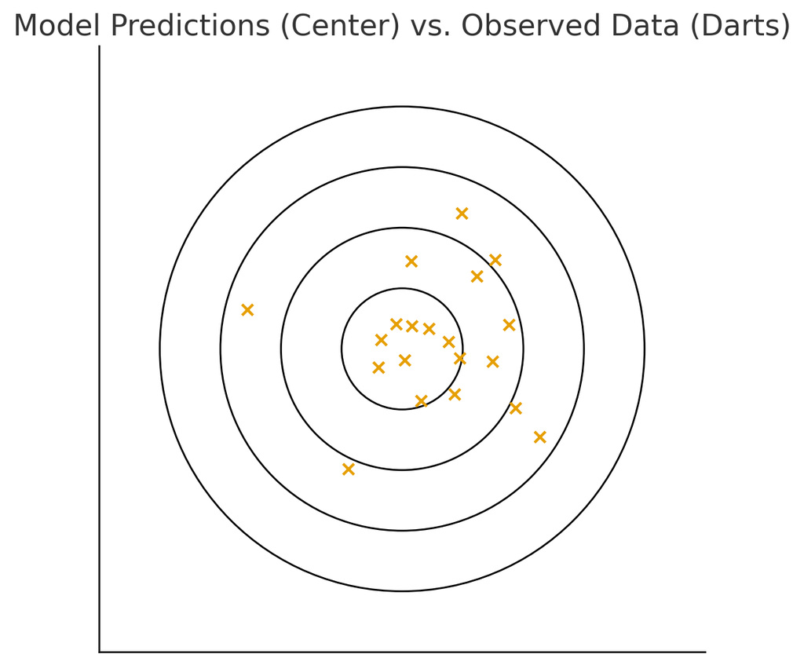

- MLE: “What’s the best dart throw?”
- Bayesian: “Given where darts tend to land, what is the distribution of possible aiming points?”

## Deriving model assumptions from the likelihood

- Shape of likelihood function gives an indication of residual behavior
- $\prod$ signals independent observations
- Moments of the distribution add assumptions (i.e. Poisson mean = variance)

# Logistic Regression and Distribution Models

## Why do we create distribution models?

- To identify important correlations between predictors and the occurrence of an event
- Generate maps of the ‘range’ or ‘niche’ of events
- Understand spatial patterns of event co-occurrence
- Forecast changes in event distributions

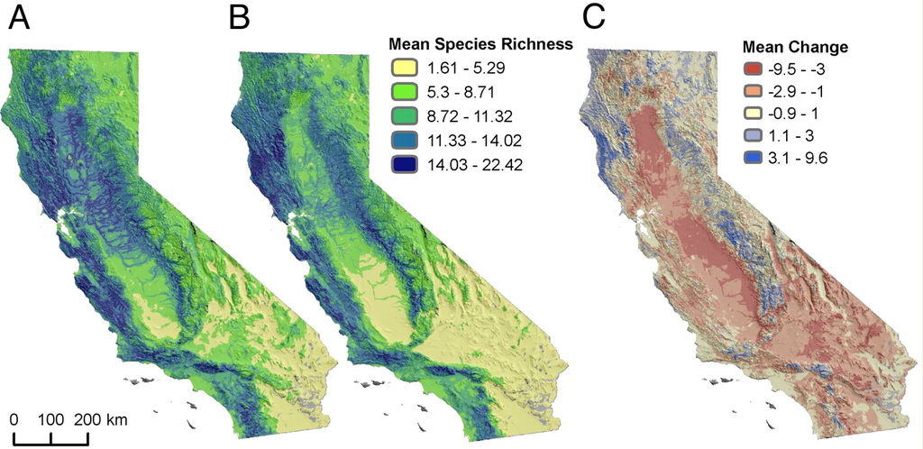

From [Wiens et al. 2009](https://www.pnas.org/content/106/Supplement_2/19729)

## General analysis situation

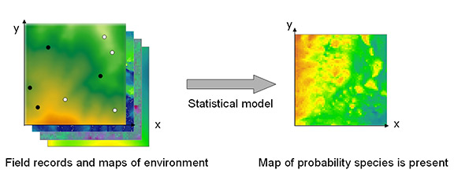

From [Long](https://www.biodiversityscience.com/2011/04/27/species-distribution-modelling/)

- Spatially referenced locations of events $(\mathbf{y})$ sampled from the study extent
- A matrix of predictors $(\mathbf{X})$ that can be assigned to each event based on spatial location

> **Goal**: Estimate the probability of occurrence of events across unsampled regions of the study area based on correlations with predictors

## Modeling Presence-Absence Data

- Random or systematic sample of the study region
- The presence (or absence) of the event is recorded for each point
- Hypothesized predictors of occurrence are measured (or extracted) at each point

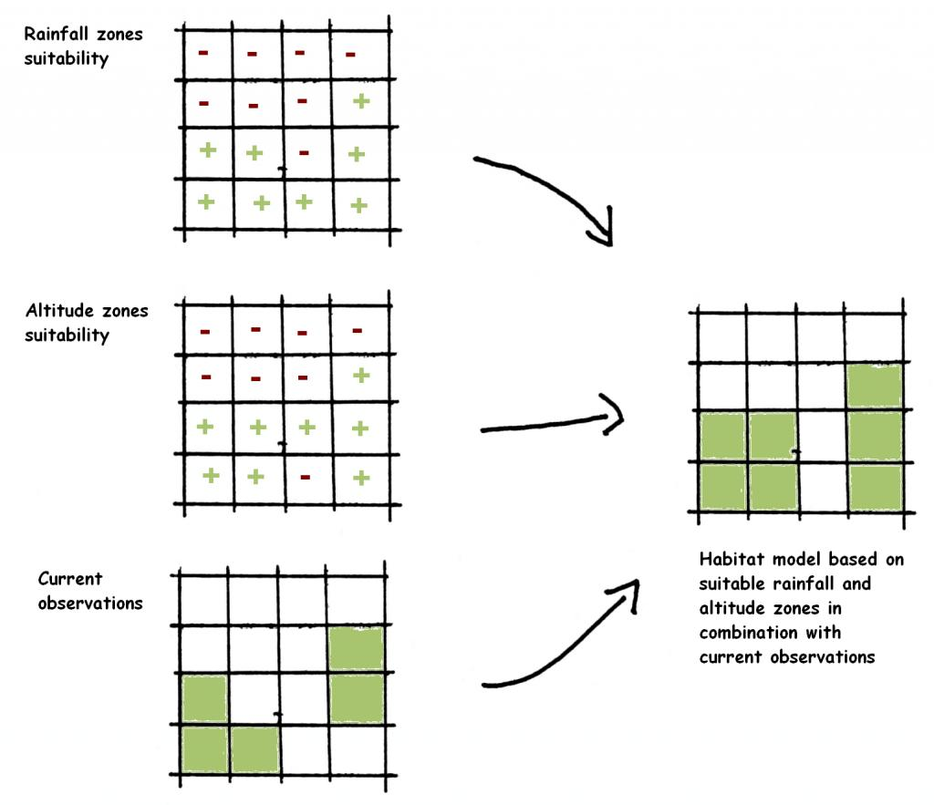

From [By Ragnvald - Own work, CC BY-SA 3.0](https://commons.wikimedia.org/w/index.php?curid=2107716)

## Logistic regression

- We can model favorability as the **probability** of occurrence using a logistic regression
- A *link* function maps the linear predictor $(\mathbf{x_i}'\beta + \alpha)$ onto the support (0-1) for probabilities
- Estimates of $\beta$ can then be used to generate ‘wall-to-wall’ spatial predictions

$$\begin{equation}
y_{i} \sim \text{Bern}(p_i)\\
\text{link}(p_i) = \mathbf{x_i}'\beta + \alpha
\end{equation}$$

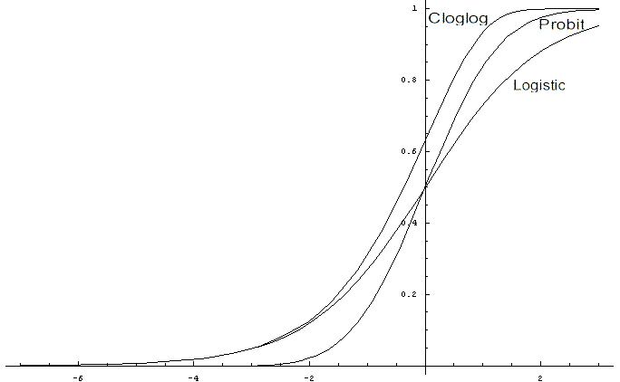

From [Mendoza](https://www.ou.edu/faculty/M/Jorge.L.Mendoza-1/comparison_of_probit.htm)

## Comparison with Machine Learning

- Statistical models describe a generative process: how’d the data get here
- Machine learning models ask something different
- Underlying modes of prediction